# P5 A Dacko

Aleksandra Dacko

10/10/2022

```r
set.seed(45)
```

# Default dataset

### 1. Create a scatterplot of the Default dataset, where balance is mapped to the x position, income is mapped to the y position, and default is mapped to the colour. Can you see any interesting patterns already?

```r
head(Default)
```

```
##   default student   balance    income
## 1      No      No  729.5265 44361.625
## 2      No     Yes  817.1804 12106.135
## 3      No      No 1073.5492 31767.139
## 4      No      No  529.2506 35704.494
## 5      No      No  785.6559 38463.496
## 6      No     Yes  919.5885  7491.559
```

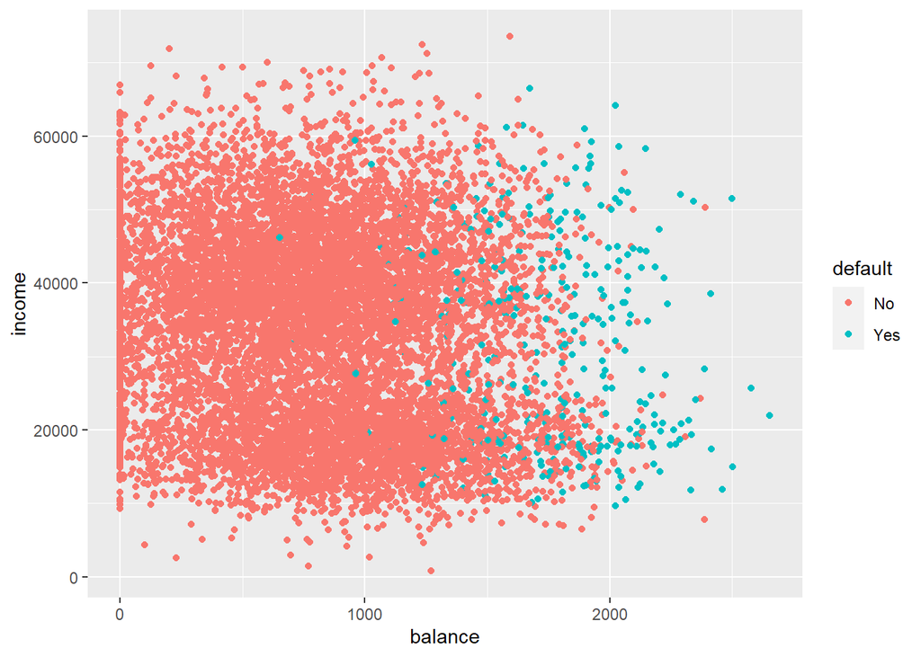

```r
Default %>% ggplot(aes(x=balance,y=income,color=default)) + geom_point()
```

### 2.Add facet_grid(cols = vars(student)) to the plot. What do you see?

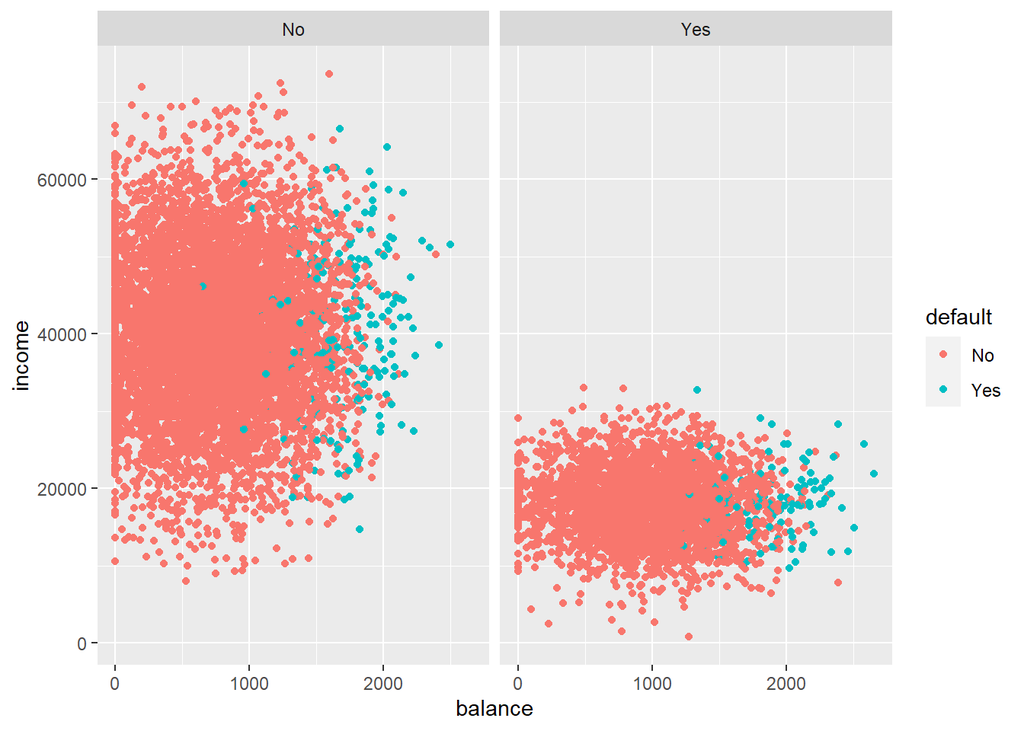

```r
Default %>% ggplot(aes(x=balance,y=income,color=default)) + geom_point()+facet_grid(cols=vars(Default$student))
```

### 3. Transform “student” into a dummy variable using ifelse() (0 = not a student, 1 = student). Then, randomly split the Default dataset into a training set default_train (80%) and a test set default_test (20%)

```r
Default %<>% mutate(student=case_when(student=="No" ~0, student=="Yes"~1))
```

```r
nobs <- nrow(Default) # Number of rows
idx_df <- 1:nobs # Indices of rows
Default<- Default[sample(idx_df), ] # Randomize
# Split the data into 80% train and 20% validation data
train_idx <- seq(1, nobs * 0.8) # Training data indices
default_train<-Default[train_idx,]
default_test<-Default[-train_idx,]
```

### 4.Create class predictions for the test set using the knn() function. Use student, balance, and income (but no basis functions of those variables) in the default_train dataset. Set k to 5. Store the predictions in a variable called knn_5_pred

```r
knn_5_pred <-knn(train=default_train[,2:4],test=default_test[,2:4], k=5,cl=as.factor(default_train[,1]))
```

### 5. Create two scatter plots with income and balance as in the first plot you made. One with the true class (default) mapped to the colour aesthetic, and one with the predicted class (knn_5_pred) mapped to the colour aesthetic.

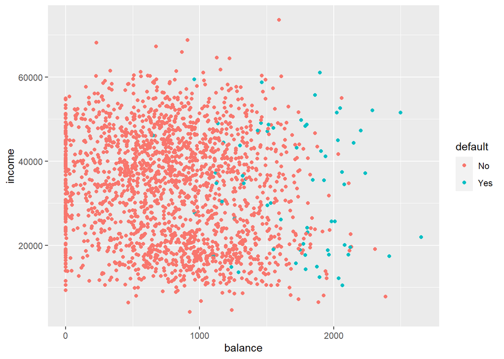

```r
default_test %>%ggplot(aes(x=balance,y=income,color=default)) + geom_point()
```

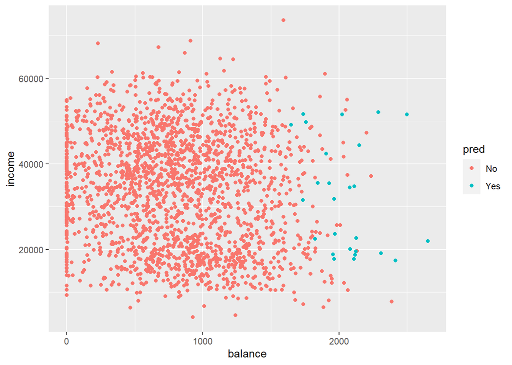

```r
bind_cols(default_test, pred = knn_5_pred) %>% arrange(default) %>% ggplot(aes(x=balance,y=income,color=pred)) + geom_point()
```

```r
table(default_test$default, pred = knn_5_pred)
```

```
##      pred
##         No  Yes
##   No  1923   10
##   Yes   51   16
```

### 6.Repeat the same steps, but now with a knn_2_pred vector generated from a 2-nearest neighbours algorithm. Are there any differences?

```r
knn_2_pred <-knn(train=default_train[,2:4],test=default_test[,2:4], k=2, cl=as.factor(default_train[,1]))
```

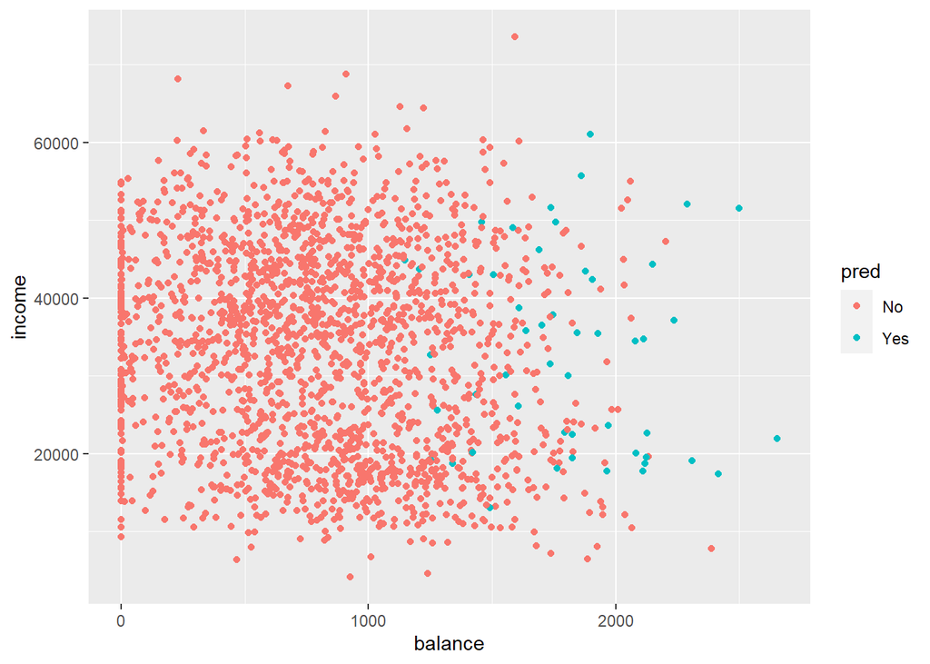

```r
bind_cols(default_test, pred = knn_2_pred) %>% arrange(default) %>% ggplot(aes(x=balance,y=income,color=pred)) + geom_point()
```

# Confusion matrix

```r
table(true=default_test$default, predicted = knn_2_pred)
```

```
##      predicted
## true    No  Yes
##   No  1901   32
##   Yes   49   18
```

5-KKN seems to perform a bit better

### 7.What would this confusion matrix look like if the classification were perfect?

```r
table(true=default_test$default, predicted = default_test$default)
```

```
##      predicted
## true    No  Yes
##   No  1933    0
##   Yes    0   67
```

### 8.Make a confusion matrix for the 5-nn model and compare it to that of the 2-nn model. What do you conclude?

```r
#5-nn model
table(default_test$default, pred = knn_5_pred)
```

```
##      pred
##         No  Yes
##   No  1923   10
##   Yes   51   16
```

```r
#2-nn model
table(true=default_test$default, predicted = knn_2_pred)
```

```
##      predicted
## true    No  Yes
##   No  1901   32
##   Yes   49   18
```

# Logistic regression

```r
lr_model<-glm(default_train, formula =default~student+balance+income, family = binomial )
prediction<-predict(lr_model,type="response")
```

### 10. Visualise the predicted probabilities versus observed class for the training dataset in lr_mod. You can choose for yourself which type of visualisation you would like to make. Write down your interpretations along with your plot.

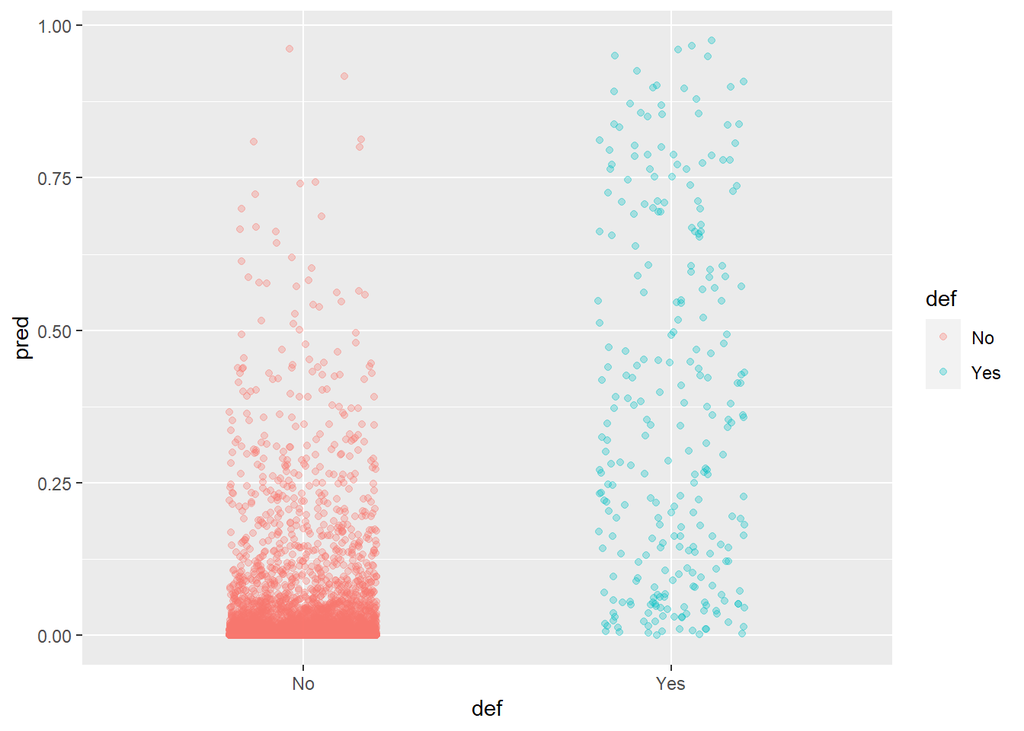

```r
bind_cols(def=default_train$default, pred = prediction)  %>% ggplot(aes(x=def,y=pred, color=def)) + geom_point(position = position_jitter(width = 0.2), alpha = .3)
```

### 11.Look at the coefficients of the lr_mod model and interpret the coefficient for balance. What would the probability of default be for a person who is not a student, has an income of 40000, and a balance of 3000 dollars at the end of each month? Is this what you expect based on the plots we’ve made before?

```r
summary(lr_model)
```

```
##
## Call:
## glm(formula = default ~ student + balance + income, family = binomial,
##     data = default_train)
##
## Deviance Residuals:
##     Min       1Q   Median       3Q      Max
## -2.5559  -0.1322  -0.0494  -0.0169   3.7509
##
## Coefficients:
##               Estimate Std. Error z value Pr(>|z|)
## (Intercept) -1.130e+01  5.760e-01 -19.619   <2e-16 ***
## student     -6.689e-01  2.704e-01  -2.474   0.0134 *
## balance      6.048e-03  2.760e-04  21.914   <2e-16 ***
## income       1.338e-06  9.436e-06   0.142   0.8872
## ---
## Signif. codes:  0 '***' 0.001 '**' 0.01 '*' 0.05 '.' 0.1 ' ' 1
##
## (Dispersion parameter for binomial family taken to be 1)
##
##     Null deviance: 2333.8  on 7999  degrees of freedom
## Residual deviance: 1217.1  on 7996  degrees of freedom
## AIC: 1225.1
##
## Number of Fisher Scoring iterations: 8
```

```r
#now we calculate the log odds
lo<-as.numeric(coefficients(lr_model)[1]+0*coefficients(lr_model)[2]+3000+coefficients(lr_model)[3]+ 4000*coef(lr_model)[4])
p<-round(1/(1+exp(-lo)),10)
p
```

```
## [1] 1
```

```r
balance_df<-data.frame(student=rep(0,500),balance=seq(from=1,to=3000,length.out=500),income=rep(mean(default_train$income),500))
```